# CA1-PDS

Name = Ye Yint Aung Admission Number = 2340656 Data Set Link: https://beta.data.gov.sg/datasets/415/view https://beta.data.gov.sg/datasets/452/resources/d_437e089ba21c5221b0d42e3b2636b7f0/view https://beta.data.gov.sg/collections/415/view

The primary information in Data Set 1 (intake, enrollment, and graduate) pertains to the total number of students enrolled in various universities for each year between 2014 and 2021. We will be able to get the total number of students from all universities using this dataset.

This output uses the Numpy library to load three data sets namely IntakebyInstitutions.csv, EnrolmentbyInstitutions.csv and Graduatesbyinstitutions.csv. Then, break down that data into useful and required subdata according to my research question. It aids in our decision-making on the type of chart to be used for data visualization in the future as well as possible subset extractions from this dataset.

```python
import numpy as np

# Importing Data from intake and Enrolment
data_intake = np.genfromtxt('IntakebyInstitutions.csv', delimiter=",", names=True,
                            dtype=['int', 'U50', 'int','int','int','int','int','int','int','int','int','int','int','int','int','int','int','int','int'])

data_enrolment = np.genfromtxt('EnrolmentbyInstitutions.csv', delimiter=",", names=True,
                               dtype=['int', 'U50', 'int','int','int','int','int','int','int','int','int','int','int','int','int','int','int','int','int'])

data_graduate = np.genfromtxt('Graduatesbyinstitutions.csv', delimiter=",", names=True,
                               dtype=['int', 'U50', 'int','int','int','int','int','int','int','int','int','int','int','int','int','int','int','int','int'])

print("Total number of rows in EnrolmentbyInstitutions.csv :", data_intake.shape[0])
print("Total number of rows in IntakebyInstitutions.csv :", data_enrolment.shape[0])
print("Total number of rows in GraduatesbyInstitutions.csv :", data_graduate.shape[0])
period = np.unique(data_intake['year'])
print(f"Every CSV files have the time period from {period[0]} to {period[-1]}")
print('There are 16 different institutions.')

mask_data_intake = (data_intake['year'] >= 2014) & (data_intake['year'] <= 2021) & (data_intake['sex'] == 'MF')
required_data_intake = np.array([data_intake[mask_data_intake]["nus"],
                                data_intake[mask_data_intake]["ntu"],
                                data_intake[mask_data_intake]["smu"],
                                data_intake[mask_data_intake]["sit"],
                                data_intake[mask_data_intake]["sutd"],
                                data_intake[mask_data_intake]["suss"]])

mask_data_enrolment = (data_enrolment['year'] >= 2014) & (data_enrolment['year'] <= 2021) & (data_enrolment['sex'] == 'MF')
required_data_enrolment = np.array([data_enrolment[mask_data_enrolment]["nus"],
                                    data_enrolment[mask_data_enrolment]["ntu"],
                                    data_enrolment[mask_data_enrolment]["smu"],
                                    data_enrolment[mask_data_enrolment]["sit"],
                                    data_enrolment[mask_data_enrolment]["sutd"],
                                    data_enrolment[mask_data_enrolment]["suss"]])

mask_data_graduate = (data_graduate['year'] >= 2014) & (data_graduate['year'] <= 2021) & (data_graduate['sex'] == 'MF')
required_data_graduate = np.array([data_graduate[mask_data_graduate]["nus"],
                                    data_graduate[mask_data_graduate]["ntu"],
                                    data_graduate[mask_data_graduate]["smu"],
                                    data_graduate[mask_data_graduate]["sit"],
                                    data_graduate[mask_data_graduate]["sutd"],
                                    data_graduate[mask_data_graduate]["suss"]])

total_intake = required_data_intake.sum(axis=0)
total_enrollment = required_data_enrolment.sum(axis=0)
total_graduates = required_data_graduate.sum(axis=0)
print(f"{'='*40}")
print(f"{'Total Students in Singapore''s Universities':^40}")
print(f"{'='*40}")
print(f"The total number of students enrolled: {total_enrollment.sum():,}")
print(f"The total number of students admitted: {total_intake.sum():,}")
print(f"The total number of students graduated: {total_graduates.sum():,}")
print(f"{'='*40}")

universities = ["NUS", "NTU", "SMU", "SIT", "SUTD", "SUSS"]
# Calculate totals for each university
total_intake_per_university = required_data_intake.sum(axis=1)
total_enrollment_per_university = required_data_enrolment.sum(axis=1)
total_graduates_per_university = required_data_graduate.sum(axis=1)

# Print totals for each university
for i, university in enumerate(universities):
    print(f"\n{'='*40}")
    print(f"{university:^40}")
    print(f"{'='*40}")
    print(f"Enrollment: {total_enrollment_per_university[i]:,}")
    print(f"Admission: {total_intake_per_university[i]:,}")
    print(f"Graduation: {total_graduates_per_university[i]:,}")
    print(f"{'='*40}")
```

```
Total number of rows in EnrolmentbyInstitutions.csv : 80
Total number of rows in IntakebyInstitutions.csv : 80
Total number of rows in GraduatesbyInstitutions.csv : 78
Every CSV files have the time period from 1982 to 2021
There are 16 different institutions.
========================================
Total Students in Singapores Universities
========================================
The total number of students enrolled: 560,522
The total number of students admitted: 156,253
The total number of students graduated: 130,634
========================================

========================================
                  NUS
========================================
Enrollment: 230,602
Admission: 59,245
Graduation: 52,230
========================================

========================================
                  NTU
========================================
Enrollment: 186,670
Admission: 50,916
Graduation: 47,297
========================================

========================================
                  SMU
========================================
Enrollment: 66,623
Admission: 17,212
Graduation: 14,350
========================================

========================================
                  SIT
========================================
Enrollment: 50,845
Admission: 20,284
Graduation: 13,045
========================================

========================================
                  SUTD
========================================
Enrollment: 11,270
Admission: 3,358
Graduation: 2,397
========================================

========================================
                  SUSS
========================================
Enrollment: 14,512
Admission: 5,238
Graduation: 1,315
========================================
```

The output plots a bar chart and line charts using the Matplotlib package to enable the user to do a basic data analysis of the enrolment, intake, and graduate statistics of Singaporean universities. The total number of students enrolled, accepted, and graduated from the six universities (NUS, NTU, SMU SIT, SUTD, and SUSS) between 2014 and 2021 is displayed in a bar chart. In six line charts, it displays the enrollment, intake, and graduation rates for each university from 2014 to 2021.

```
The output plots a bar chart and line charts using the Matplotlib package to enable the user to do a basic data analysis of the enrolment, intake, and graduate statistics of Singaporean universities. The total number of students enrolled, accepted, and graduated from the six universities (NUS, NTU, …
```

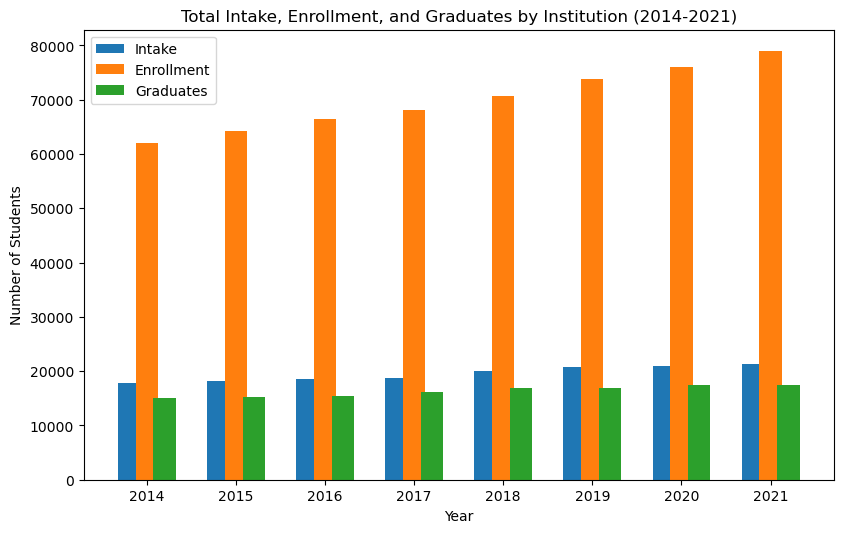

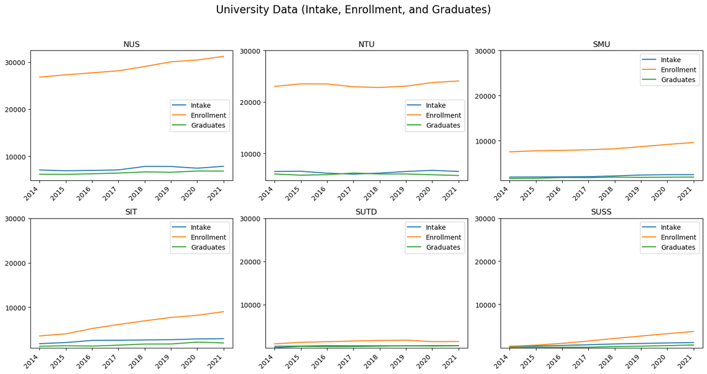

```python
import numpy as np
import matplotlib.pyplot as plt

# Importing Data from intake and Enrolment
data_intake = np.genfromtxt('IntakebyInstitutions.csv', delimiter=",", names=True,
                            dtype=['int', 'U50', 'int','int','int','int','int','int','int','int','int','int','int','int','int','int','int','int','int'])

data_enrolment = np.genfromtxt('EnrolmentbyInstitutions.csv', delimiter=",", names=True,
                               dtype=['int', 'U50', 'int','int','int','int','int','int','int','int','int','int','int','int','int','int','int','int','int'])

data_graduate = np.genfromtxt('Graduatesbyinstitutions.csv', delimiter=",", names=True,
                               dtype=['int', 'U50', 'int','int','int','int','int','int','int','int','int','int','int','int','int','int','int','int','int'])

mask_data_intake = (data_intake['year'] >= 2014) & (data_intake['year'] <= 2021) & (data_intake['sex'] == 'MF')
required_data_intake = np.array([data_intake[mask_data_intake]["nus"],
                                data_intake[mask_data_intake]["ntu"],
                                data_intake[mask_data_intake]["smu"],
                                data_intake[mask_data_intake]["sit"],
                                data_intake[mask_data_intake]["sutd"],
                                data_intake[mask_data_intake]["suss"]])

mask_data_enrolment = (data_enrolment['year'] >= 2014) & (data_enrolment['year'] <= 2021) & (data_enrolment['sex'] == 'MF')
required_data_enrolment = np.array([data_enrolment[mask_data_enrolment]["nus"],
                                    data_enrolment[mask_data_enrolment]["ntu"],
                                    data_enrolment[mask_data_enrolment]["smu"],
                                    data_enrolment[mask_data_enrolment]["sit"],
                                    data_enrolment[mask_data_enrolment]["sutd"],
                                    data_enrolment[mask_data_enrolment]["suss"]])

mask_data_graduate = (data_graduate['year'] >= 2014) & (data_graduate['year'] <= 2021) & (data_graduate['sex'] == 'MF')
required_data_graduate = np.array([data_graduate[mask_data_graduate]["nus"],
                                    data_graduate[mask_data_graduate]["ntu"],
                                    data_graduate[mask_data_graduate]["smu"],
                                    data_graduate[mask_data_graduate]["sit"],
                                    data_graduate[mask_data_graduate]["sutd"],
                                    data_graduate[mask_data_graduate]["suss"]])

universities = ["NUS", "NTU", "SMU", "SIT", "SUTD", "SUSS"]
print('The output plots a bar chart and line charts using the Matplotlib package to enable the user to do a basic data analysis of the enrolment, intake, and graduate statistics of Singaporean universities. The total number of students enrolled, accepted, and graduated from the six universities (NUS, NTU, SMU SIT, SUTD, and SUSS) between 2014 and 2021 is displayed in a bar chart. In six line charts, it displays the enrollment, intake, and graduation rates for each university from 2014 to 2021.')
# Bar plot for total intake, enrollment, and graduates in the center
plt.figure(figsize=(10, 6))
years = np.arange(2014, 2022)
total_intake = required_data_intake.sum(axis=0)
total_enrollment = required_data_enrolment.sum(axis=0)
total_graduates = required_data_graduate.sum(axis=0)

plt.bar(years - 0.2, total_intake, width=0.25, label='Intake', align='center')
plt.bar(years, total_enrollment, width=0.25, label='Enrollment', align='center')
plt.bar(years + 0.2, total_graduates, width=0.25, label='Graduates', align='center')

plt.legend()
plt.xlabel('Year')
plt.ylabel('Number of Students')
plt.title('Total Intake, Enrollment, and Graduates by Institution (2014-2021)')

# Set the position to be in the center
plt.gca().set_position([0.1, 0.1, 0.75, 0.75])

# Show the plot
plt.show()

# Create subplots
fig, axes = plt.subplots(nrows=2, ncols=3, figsize=(15, 8))
fig.suptitle('University Data (Intake, Enrollment, and Graduates)', fontsize=16)

for i, ax in enumerate(axes.flatten()):
    # Plot the data
    ax.plot(required_data_intake[i], label="Intake")
    ax.plot(required_data_enrolment[i], label="Enrollment")
    ax.plot(required_data_graduate[i], label="Graduates")

    # Set y-axis ticks
    ax.set_yticks([10000, 20000, 30000])

    # Set x-axis ticks
    ax.set_xticks(np.arange(8))
    ax.set_xticklabels(np.arange(2014, 2022), rotation=45, ha='right')

    # Set title and legend
    ax.set_title(universities[i])
    ax.legend()

# Adjust layout
plt.tight_layout(rect=[0, 0, 1, 0.95])

# Show the plot
plt.show()
```

RQ. What are the total number of students that each course in every unversities admits, enrolls and graduate. The number of students that each course accepts, enrolls, and graduates is provided by Data Set 2 (Intake, Enrollment, and Graduates of Each Course). We can obtain information on the total number of students each year in every course this data set.

For this part, first I use re and io library to change the commmas in csv file to semi-colons, and use numpy genfromtxt with delimter ; to retrieve data. Then breakdown the data into each courses make it more readable.

```python
import re
import numpy as np
from io import StringIO
import matplotlib.pyplot as plt

def convert_csv_to_np(file_path):
    # Read the CSV file as text
    with open(file_path, 'r') as file:
        data = file.read()

    # Define a regular expression pattern to match commas outside double quotes
    pattern = re.compile(r',(?=(?:[^"]*"[^"]*")*[^"]*$)')

    # Replace commas with semicolons
    modified_data = re.sub(pattern, ';', data)

    # Remove double quotes
    modified_data = modified_data.replace('"', '')

    # Create a file-like object from the modified string
    modified_file = StringIO(modified_data)

    # Specify the dtype based on your actual data structure
    dtype = np.dtype([("year", int), ("sex", 'U50'), ("course", 'U50'), ("intake", int), ("enrolment", int), ("graduates", int)])

    # Use np.genfromtxt to read the modified data
    real_data = np.genfromtxt(modified_file, delimiter=";", names=True, dtype=dtype)

    return real_data

file_path = 'UniversitiesIntakeEnrolmentandGraduatesbyCourse.csv'
real_data = convert_csv_to_np(file_path)
distinct_courses = np.unique(required_data['course'])

#The properties of data set
print(f'Total numbers of row in UniversitiesIntakeEnrolmentandGraduatesbyCourse.csv: {real_data.shape[0]}')
print(f'This files has {distinct_courses.size} course.')
print("It has the statistics about intakes, enrolment and graduates of differernt course.")

mask_required_data = real_data['sex'] == "MF"
required_data = real_data[mask_required_data]




for course in distinct_courses:
    mask_course = required_data['course'] == course
    course_data = required_data[mask_course]
    total_enrolment = 0
    total_intake = 0
    total_graduate = 0
    for i in course_data:
        total_intake += i[3]
        total_enrolment += i[4]
        total_graduate += i[5]

    # Print summary
    print(f"\n{'='*50}")
    print(f"{course:^50}")
    print(f"{'='*50}")
    print(f"Total Enrolment: {total_enrolment}")
    print(f"Total Intake: {total_intake}")
    print(f"Total Graduates: {total_graduate}")
    print()
```

[output not shown]

```
the proportion of students who enroll, complete, and graduate from each course.
To illustrate the proportion of each course, I have created three pie charts in this section: enrollment, intake, and graduates.
```

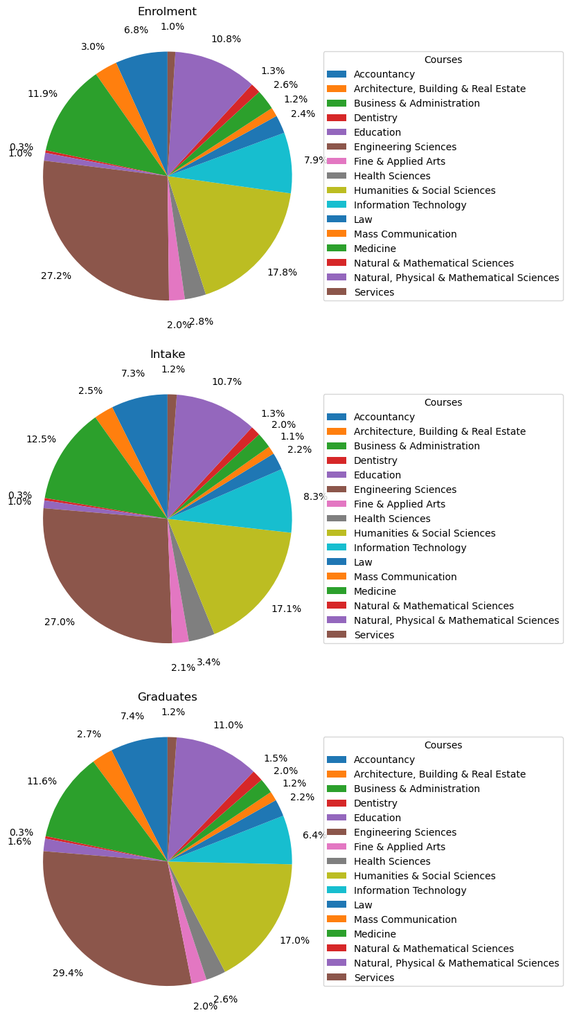

```python
import re
import numpy as np
from io import StringIO
import matplotlib.pyplot as plt

def convert_csv_to_np(file_path):
    # Read the CSV file as text
    with open(file_path, 'r') as file:
        data = file.read()

    # Define a regular expression pattern to match commas outside double quotes
    pattern = re.compile(r',(?=(?:[^"]*"[^"]*")*[^"]*$)')

    # Replace commas with semicolons
    modified_data = re.sub(pattern, ';', data)

    # Remove double quotes
    modified_data = modified_data.replace('"', '')

    # Create a file-like object from the modified string
    modified_file = StringIO(modified_data)

    # Specify the dtype based on your actual data structure
    dtype = np.dtype([("year", int), ("sex", 'U50'), ("course", 'U50'), ("intake", int), ("enrolment", int), ("graduates", int)])

    # Use np.genfromtxt to read the modified data
    real_data = np.genfromtxt(modified_file, delimiter=";", names=True, dtype=dtype)

    return real_data

# Example usage:
file_path = 'UniversitiesIntakeEnrolmentandGraduatesbyCourse.csv'
real_data = convert_csv_to_np(file_path)
mask_required_data = real_data['sex'] == "MF"
required_data = real_data[mask_required_data]

distinct_courses = np.unique(required_data['course'])
intake_data = []
enrolment_data = []
graduates_data = []
for course in distinct_courses:
    mask_course = required_data['course'] == course
    course_data = required_data[mask_course]
    enrolment = course_data['enrolment'].sum()
    enrolment_data.append(enrolment)

    intake = course_data['intake'].sum()
    intake_data.append(intake)

    graduates = course_data['graduates'].sum()
    graduates_data.append(graduates)

# Create a 3x1 subplots layout for vertical pie charts
fig, axes = plt.subplots(3, 1, figsize=(8, 15))

# Pie chart for enrolment
_, texts, autotexts = axes[0].pie(enrolment_data, autopct='%1.1f%%', startangle=90, pctdistance=1.2)
axes[0].set_title('Enrolment')
axes[0].legend(distinct_courses, title="Courses", bbox_to_anchor=(1, 0.5), loc="center left", borderaxespad=0.)

# Pie chart for intake
_, texts, autotexts = axes[1].pie(intake_data, autopct='%1.1f%%', startangle=90, pctdistance=1.2)
axes[1].set_title('Intake')
axes[1].legend(distinct_courses, title="Courses", bbox_to_anchor=(1, 0.5), loc="center left", borderaxespad=0.)

# Pie chart for graduates
_, texts, autotexts = axes[2].pie(graduates_data, autopct='%1.1f%%', startangle=90, pctdistance=1.2)
axes[2].set_title('Graduates')
axes[2].legend(distinct_courses, title="Courses", bbox_to_anchor=(1, 0.5), loc="center left", borderaxespad=0.)

plt.tight_layout()
print("the proportion of students who enroll, complete, and graduate from each course.")
print("To illustrate the proportion of each course, I have created three pie charts in this section: enrollment, intake, and graduates.")
plt.show()
```

Data sets 3 (GraduateEmploymentSurveyNTUNUSSITSMUSUSSSUTD) include employment rate, gross monthly income, and basic monthly income statistics. I will be able to obtain the employment rate of full-time and permanent occupations, as well as the basic and gross monthly means, from this data collection.

```python
import re
import numpy as np
import matplotlib.pyplot as plt
from io import StringIO

def convert_csv_to_np(file_path):
    # Read the CSV file as text
    with open(file_path, 'r') as file:
        data = file.read()

    # Define a regular expression pattern to match commas outside double quotes
    pattern = re.compile(r',(?=(?:[^"]*"[^"]*")*[^"]*$)')

    # Replace commas with semicolons
    modified_data = re.sub(pattern, ';', data)

    # Remove double quotes
    modified_data = modified_data.replace('"', '')

    # Remove #
    modified_data = modified_data.replace('#', '')

    # Create a file-like object from the modified string
    modified_file = StringIO(modified_data)

    # Specify the dtype based on your actual data structure
    dtype = np.dtype([
        ("year", int),
        ("university", 'U50'),
        ("school", 'U50'),
        ("degree", 'U50'),
        ("employment_rate_overall", float),
        ("employment_rate_ft_perm", float),
        ("basic_monthly_mean", int),
        ("basic_monthly_median", int),
        ("gross_monthly_mean", int),
        ("gross_monthly_median", int),
        ("gross_mthly_25_percentile", int),
        ("gross_mthly_75_percentile", int)
    ])

    # Use np.genfromtxt to read the modified data
    real_data = np.genfromtxt(modified_file, delimiter=";", names=True, dtype=dtype)

    return real_data


file_path = 'GraduateEmploymentSurveyNTUNUSSITSMUSUSSSUTD.csv'
real_data = convert_csv_to_np(file_path)
mask_required_data = (real_data["basic_monthly_mean"] != -1) | (real_data["basic_monthly_median"] != -1)
required_data = real_data[mask_required_data]
distinct_uni = np.unique(required_data['university'])
distinct_year = np.unique(required_data['year'])

#Information of data set
print(f'Total number of rows in GraduateEmploymentSurveyNTUNUSSITSMUSUSSSUTD.csv: {real_data.shape[0]}')
print(f"There are {distinct_uni.size} universitites in the dataset.")
print(f'The time period in this dataset range from {distinct_year[0]} to {distinct_year[-1]}')
# Exclude rows where any value (other than 'basic_monthly_mean') is equal to -1




for year in distinct_year:
    print("="*60)
    print(f"{year:^60}")
    print("="*60)
    for uni in distinct_uni:
        mask_uni = (required_data["university"] == uni) & (required_data["year"] == year)
        uni_data_basic_monthly_mean = required_data[mask_uni]["basic_monthly_mean"].mean()
        print(f"University: {uni:<30} | Mean Basic Monthly Mean: {uni_data_basic_monthly_mean:.2f}")
```

```
Total number of rows in GraduateEmploymentSurveyNTUNUSSITSMUSUSSSUTD.csv: 1121
There are 6 universitites in the dataset.
The time period in this dataset range from 2013 to 2021
============================================================
                            2013
============================================================
University: Nanyang Technological University | Mean Basic Monthly Mean: 3095.66
University: National University of Singapore | Mean Basic Monthly Mean: 3229.24
University: Singapore Institute of Technology | Mean Basic Monthly Mean: nan
University: Singapore Management University | Mean Basic Monthly Mean: 3750.00
University: Singapore University of Social Sciences | Mean Basic Monthly Mean: nan
University: Singapore University of Technology and Design | Mean Basic Monthly Mean: nan
============================================================
                            2014
============================================================
University: Nanyang Technological University | Mean Basic Monthly Mean: 3159.03
University: National University of Singapore | Mean Basic Monthly Mean: 3346.12
University: Singapore Institute of Technology | Mean Basic Monthly Mean: 2945.92
University: Singapore Management University | Mean Basic Monthly Mean: 3838.00
University: Singapore University of Social Sciences | Mean Basic Monthly Mean: nan
University: Singapore University of Technology and Design | Mean Basic Monthly Mean: nan
============================================================
                            2015
============================================================
University: Nanyang Technological University | Mean Basic Monthly Mean: 3303.91
University: National University of Singapore | Mean Basic Monthly Mean: 3439.78
University: Singapore Institute of Technology | Mean Basic Monthly Mean: 3007.68
University: Singapore Management University | Mean Basic Monthly Mean: 3900.33
University: Singapore University of Social Sciences | Mean Basic Monthly Mean: nan
University: Singapore University of Technology and Design | Mean Basic Monthly Mean: 3722.00
============================================================
                            2016
============================================================
University: Nanyang Technological University | Mean Basic Monthly Mean: 3315.82
University: National University of Singapore | Mean Basic Monthly Mean: 3514.91
University: Singapore Institute of Technology | Mean Basic Monthly Mean: 3166.54
University: Singapore Management University | Mean Basic Monthly Mean: 3992.08
University: Singapore University of Social Sciences | Mean Basic Monthly Mean: nan
University: Singapore University of Technology and Design | Mean Basic Monthly Mean: 3837.33
============================================================
```

[output cut: 29 more lines]

```
University: Nanyang Technological University | Mean Basic Monthly Mean: 3716.47
University: National University of Singapore | Mean Basic Monthly Mean: 4072.03
University: Singapore Institute of Technology | Mean Basic Monthly Mean: 3537.68
University: Singapore Management University | Mean Basic Monthly Mean: 4310.75
University: Singapore University of Social Sciences | Mean Basic Monthly Mean: 3159.43
University: Singapore University of Technology and Design | Mean Basic Monthly Mean: 4120.50
============================================================
                            2021
============================================================
University: Nanyang Technological University | Mean Basic Monthly Mean: 3837.08
University: National University of Singapore | Mean Basic Monthly Mean: 4166.21
University: Singapore Institute of Technology | Mean Basic Monthly Mean: 3614.45
University: Singapore Management University | Mean Basic Monthly Mean: 4602.58
University: Singapore University of Social Sciences | Mean Basic Monthly Mean: 3431.38
University: Singapore University of Technology and Design | Mean Basic Monthly Mean: 4331.25
```

```
The provided histogram display the frequency gross monthly mean from S$2000 to S$7000
```

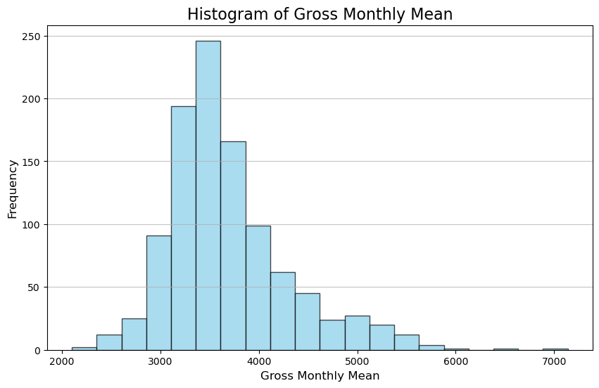

```python
import re
import numpy as np
import matplotlib.pyplot as plt
from io import StringIO

def convert_csv_to_np(file_path):
    # Read the CSV file as text
    with open(file_path, 'r') as file:
        data = file.read()

    # Define a regular expression pattern to match commas outside double quotes
    pattern = re.compile(r',(?=(?:[^"]*"[^"]*")*[^"]*$)')

    # Replace commas with semicolons
    modified_data = re.sub(pattern, ';', data)

    # Remove double quotes
    modified_data = modified_data.replace('"', '')

    # Remove #
    modified_data = modified_data.replace('#', '')

    # Create a file-like object from the modified string
    modified_file = StringIO(modified_data)

    # Specify the dtype based on your actual data structure
    dtype = np.dtype([
        ("year", int),
        ("university", 'U50'),
        ("school", 'U50'),
        ("degree", 'U50'),
        ("employment_rate_overall", float),
        ("employment_rate_ft_perm", float),
        ("basic_monthly_mean", int),
        ("basic_monthly_median", int),
        ("gross_monthly_mean", int),
        ("gross_monthly_median", int),
        ("gross_mthly_25_percentile", int),
        ("gross_mthly_75_percentile", int)
    ])

    # Use np.genfromtxt to read the modified data
    real_data = np.genfromtxt(modified_file, delimiter=";", names=True, dtype=dtype)

    return real_data

# Example usage:
file_path = 'GraduateEmploymentSurveyNTUNUSSITSMUSUSSSUTD.csv'
real_data = convert_csv_to_np(file_path)

# Exclude rows where any value (other than 'basic_monthly_mean') is equal to -1
mask_required_data = (real_data["basic_monthly_mean"] != -1) | (real_data["basic_monthly_median"] != -1)
required_data = real_data[mask_required_data]["gross_monthly_mean"]

# Plotting the histogram with a visually appealing style
plt.figure(figsize=(10, 6))  # Adjust the figure size

plt.hist(required_data, bins=20, color='skyblue', edgecolor='black', alpha=0.7)  # Use a soothing color and add transparency
plt.title('Histogram of Gross Monthly Mean', fontsize=16)
plt.xlabel('Gross Monthly Mean', fontsize=12)
plt.ylabel('Frequency', fontsize=12)
plt.grid(axis='y', alpha=0.75)
print("The provided histogram display the frequency gross monthly mean from S$2000 to S$7000")
plt.show()
```

```
The below scatter plot shows the mean of fulltime and permanent employment of each university between 2013 and 2021
```

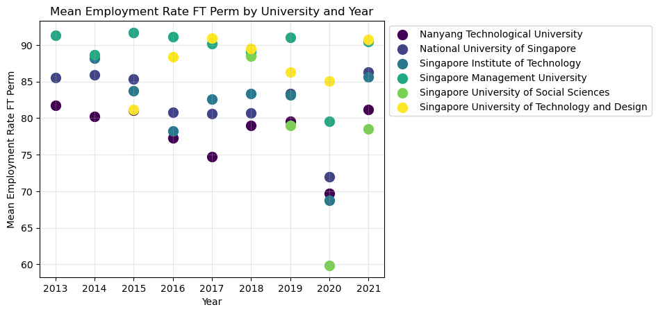

```python
import re
import numpy as np
import matplotlib.pyplot as plt
from io import StringIO

def convert_csv_to_np(file_path):
    # Read the CSV file as text
    with open(file_path, 'r') as file:
        data = file.read()

    # Define a regular expression pattern to match commas outside double quotes
    pattern = re.compile(r',(?=(?:[^"]*"[^"]*")*[^"]*$)')

    # Replace commas with semicolons
    modified_data = re.sub(pattern, ';', data)

    # Remove double quotes
    modified_data = modified_data.replace('"', '')

    # Remove #
    modified_data = modified_data.replace('#', '')

    # Create a file-like object from the modified string
    modified_file = StringIO(modified_data)

    # Specify the dtype based on your actual data structure
    dtype = np.dtype([
        ("year", int),
        ("university", 'U50'),
        ("school", 'U50'),
        ("degree", 'U50'),
        ("employment_rate_overall", float),
        ("employment_rate_ft_perm", float),
        ("basic_monthly_mean", int),
        ("basic_monthly_median", int),
        ("gross_monthly_mean", int),
        ("gross_monthly_median", int),
        ("gross_mthly_25_percentile", int),
        ("gross_mthly_75_percentile", int)
    ])

    # Use np.genfromtxt to read the modified data
    real_data = np.genfromtxt(modified_file, delimiter=";", names=True, dtype=dtype)

    return real_data

# Example usage:
file_path = 'GraduateEmploymentSurveyNTUNUSSITSMUSUSSSUTD.csv'
real_data = convert_csv_to_np(file_path)

# Exclude rows where any value (other than 'basic_monthly_mean') is equal to -1
mask_required_data = (real_data["basic_monthly_mean"] != -1) | (real_data["basic_monthly_median"] != -1)
required_data = real_data[mask_required_data]

# Get the unique years and universities
distinct_years = np.unique(required_data['year'])
distinct_uni = np.unique(required_data['university'])

# Set up a colormap for better differentiation between universities
colors = plt.cm.viridis(np.linspace(0, 1, len(distinct_uni)))

# Create a scatter plot for each university and each year
for uni, color in zip(distinct_uni, colors):
    uni_means = []  # Store mean employment_rate_ft_perm for each year
    for year in distinct_years:
        mask_year_uni = (required_data['year'] == year) & (required_data['university'] == uni)
        year_uni_data = required_data[mask_year_uni]
        mean_ft_perm = year_uni_data["employment_rate_ft_perm"].mean()
        uni_means.append(mean_ft_perm)

    plt.scatter(distinct_years, uni_means, label=uni, color=color, marker='o', s=100)

# Add labels, legend, and grid lines
plt.xlabel('Year')
plt.ylabel('Mean Employment Rate FT Perm')
plt.title('Mean Employment Rate FT Perm by University and Year')
# Reduce grid transparency
plt.grid(alpha=0.3)
plt.legend(loc='upper left', bbox_to_anchor=(1, 1))
print("The below scatter plot shows the mean of fulltime and permanent employment of each university between 2013 and 2021")
plt.show()
```

# Conclusion

Data Set 3 According to data set 3, the average monthly gross income of graduate students is around S$3500, while the highest-paid graduate receives S$7000. Additionally, SMU has the highest average employment rate of fulltme jobs from 2013 to 2016, and 2019, while SUTD tops 2017, 2018, 2020 and 2021.